# Analyzing Individual BGG Users

Phil Henrickson

2022-01-03

# **ryin12’s** BoardGameGeek Collection

This notebook contains a set of analyses for the selected user’s boardgamegeek collection. The bulk of the analysis is focused on building a user-specific predictive model to predict the games that ryin12 is likely to own. This enables to ask questions like, based on the games the user currently owns, what games are a good fit for their collection? What upcoming games are they likely to purchase?

This analysis is based on data from BoardGameGeek that was last updated on **2021-12-20.**

# 1 Collection Overview

We can look at a basic description of the number of games that the user owns, has rated, has previously owned, etc.

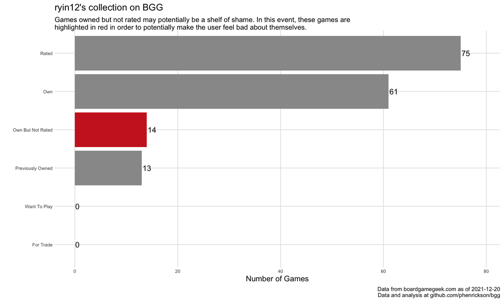

What years has the user owned/rated games from? While we can’t see when a user added or removed a game from their collection, we can look at their collection by the years in which their games were published.

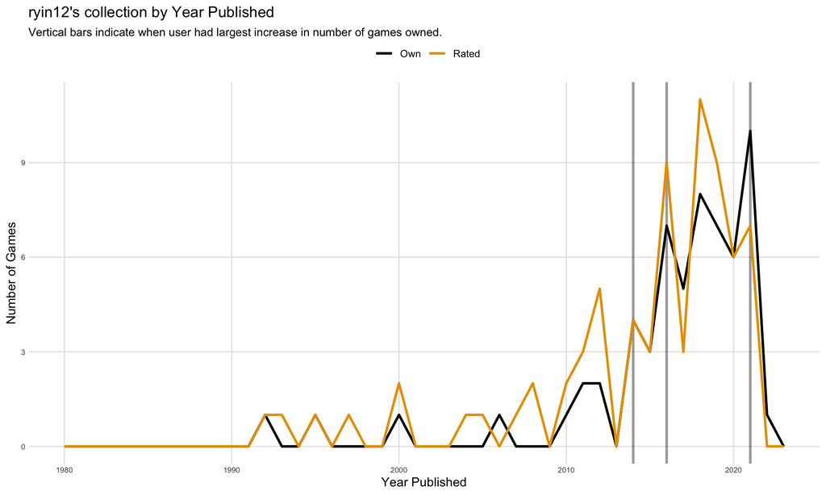

## 1.1 What types of games does ryin12 own?

We can look at the most frequent types of categories, mechanics, designers, and artists that appear in a user’s collection.

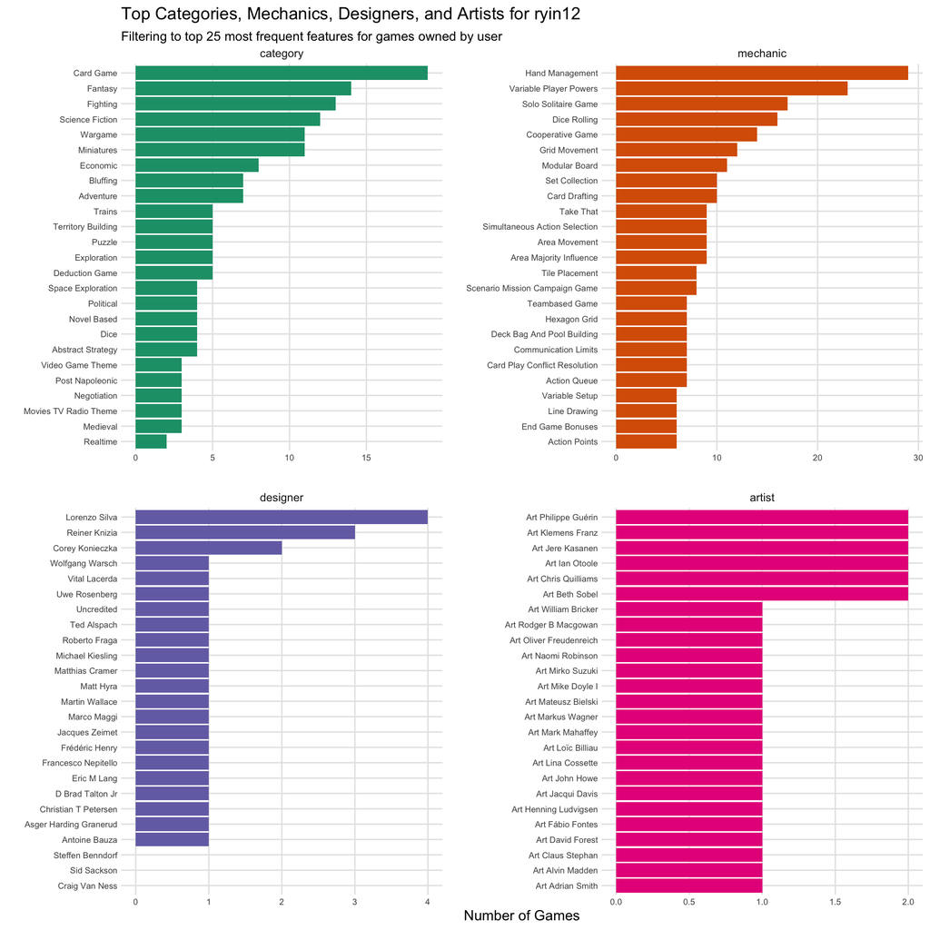

# 2 Modeling **ryin12’s** Collection

| username | dataset | period | games_owned | games_rated | games_played |
| --- | --- | --- | --- | --- | --- |
| ryin12 | training | published before 2020 | 42 | 58 | 69 |
| ryin12 | test | published 2020 or later | 17 | 13 | 19 |

There are two main (binary) outcomes we will be modeling for the user.

The first, **own** refers to whether the user currently lists a game as owned in their collection. The second, **played** refers to whether the user currently owns, has rated, or previously owned a game. This means the latter will generally have a larger list of games, but may still be a useful category to examine for people who play lots of games without necessarily owning them.

We will train predictive models to learn the probability that the user will own or play individual games based on their features.

## 2.1 Coefficients for ryin12

We can examine coefficients from the trained modes, which are penalized logistic regressions fit to our two main outcomes. Positive values indicate that a feature increases a user’s probabilility of owning/rating a game, while negative values indicate a feature decreases the probability.

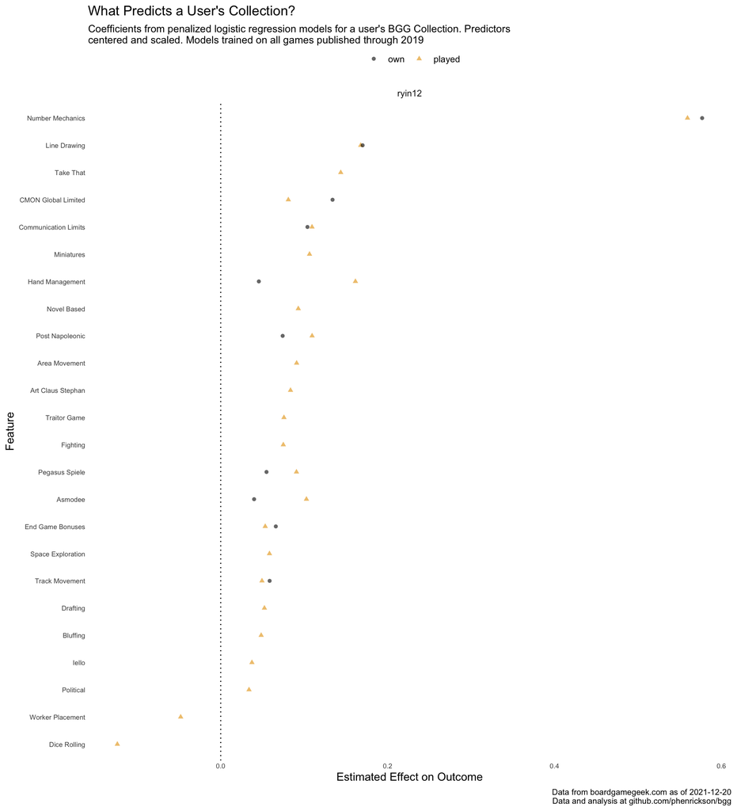

## 2.2 Visualizing Predictors for ryin12’s Collection

Why did the model identify these features? We can make density plots of the important features for predicting whether the user owned a game. Blue indicates the density for games owned by the user, while grey indicates the density for games not owned by the user.

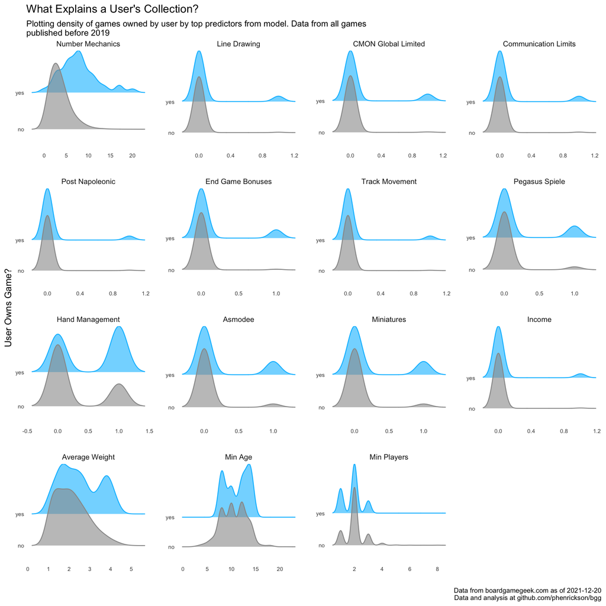

Binary predictors can be difficult to see with this visualization, so we can also directly examine the percentage of games in a user’s collection with a predictor vs the percentage of all games with that predictor.

| username | Feature | % of Games with Feature In_Collection | % of Games with Feature All_Games | Ratio |
| --- | --- | --- | --- | --- |
| ryin12 | CMON Global Limited | 11.9% | 0.8% | 15.4 |
| ryin12 | Line Drawing | 9.5% | 0.7% | 13.8 |
| ryin12 | End Game Bonuses | 14.3% | 1.2% | 11.6 |
| ryin12 | Track Movement | 7.1% | 0.6% | 11.2 |
| ryin12 | Income | 7.1% | 0.7% | 10.2 |
| ryin12 | Communication Limits | 9.5% | 1.0% | 9.9 |
| ryin12 | Post Napoleonic | 7.1% | 0.9% | 8.1 |
| ryin12 | Miniatures | 21.4% | 5.3% | 4.1 |
| ryin12 | Pegasus Spiele | 19.0% | 4.7% | 4.0 |
| ryin12 | Asmodee | 21.4% | 5.3% | 4.0 |
| ryin12 | Mafia | 2.4% | 0.7% | 3.4 |
| ryin12 | Trains | 7.1% | 2.2% | 3.3 |
| ryin12 | Hand Management | 54.8% | 26.6% | 2.1 |
| ryin12 | Puzzle | 7.1% | 3.4% | 2.1 |
| ryin12 | Negotiation | 7.1% | 3.6% | 2.0 |
| ryin12 | Racing | 2.4% | 2.8% | 0.9 |
| ryin12 | Medieval | 4.8% | 6.3% | 0.8 |
| ryin12 | City Building | 2.4% | 4.3% | 0.6 |
| ryin12 | Realtime | 2.4% | 4.2% | 0.6 |
| ryin12 | Action Dexterity | 2.4% | 4.8% | 0.5 |
| ryin12 | Party Game | 2.4% | 8.5% | 0.3 |
| ryin12 | Horror | 0.0% | 4.0% | 0.0 |
| ryin12 | Word Game | 0.0% | 1.8% | 0.0 |
| ryin12 | Trivia | 0.0% | 1.8% | 0.0 |
| ryin12 | Prehistoric | 0.0% | 1.0% | 0.0 |

# 3 Assess Model’s Performance on Training Set

Before predicting games in upcoming years, we can examine how well the model did and what games it liked in the training set. In this case, we used resampling techniques (cross validation) to ensure that the model had not seen a game before making its predictions.

## 3.1 Separation Plot

An easy way to examine the performance of classification model is to view a separation plot. We plot the predicted probabilities from the model for every game (from resampling) from lowest to highest. We then overlay a blue line for any game that the user does own. A good classifier is one that is able to *separate* the blue (games owned by the user) from the white (games not owned by the user), with most of the blue occurring at the highest probabilities (right side of the chart).

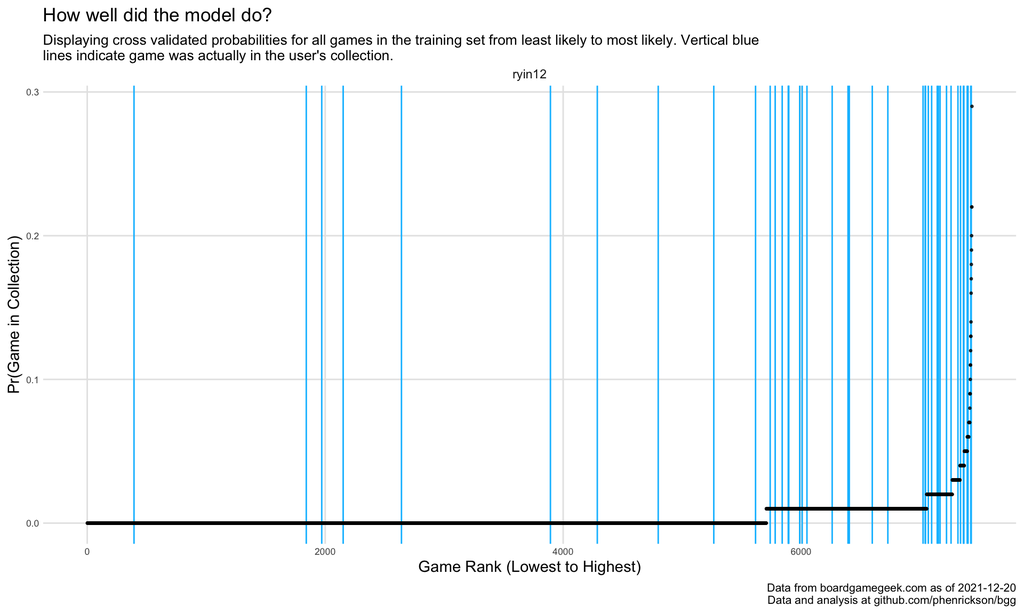

## 3.2 Top Games for **ryin12** from Training Set

We can display this information in table form, displaying the 100 games with the highest probability of ownership, adding a blue line when the user does own the game.

| username | yearpublished | game_id | name | pred_played | pred_own | actual_played | actual_own |
| --- | --- | --- | --- | --- | --- | --- | --- |
| ryin12 | 2019 | 265736 | Tiny Towns | 0.18 | 0.29 | 0 | 0 |
| ryin12 | 2019 | 257066 | Sierra West | 0.12 | 0.22 | 0 | 0 |
| ryin12 | 2007 | 29937 | König von Siam | 0.12 | 0.22 | 0 | 0 |
| ryin12 | 2019 | 283863 | The Magnificent | 0.34 | 0.20 | 0 | 0 |
| ryin12 | 2019 | 270971 | Era: Medieval Age | 0.20 | 0.19 | 0 | 0 |
| ryin12 | 2018 | 231327 | The Grizzled: Armistice Edition | 0.22 | 0.18 | 0 | 0 |
| ryin12 | 2018 | 205896 | Rising Sun | 0.76 | 0.17 | 1 | 1 |
| ryin12 | 2010 | 73171 | Earth Reborn | 0.27 | 0.16 | 0 | 0 |
| ryin12 | 2018 | 259809 | Sonar Family | 0.10 | 0.14 | 0 | 0 |
| ryin12 | 2017 | 174430 | Gloomhaven | 0.73 | 0.13 | 1 | 1 |
| ryin12 | 2015 | 163967 | Tiny Epic Galaxies | 0.09 | 0.13 | 0 | 0 |
| ryin12 | 2018 | 209324 | The World of SMOG: Rise of Moloch | 0.23 | 0.12 | 0 | 0 |
| ryin12 | 2015 | 175878 | 504 | 0.31 | 0.11 | 0 | 0 |
| ryin12 | 1976 | 3083 | Submarine | 0.07 | 0.11 | 0 | 0 |
| ryin12 | 2012 | 122515 | Keyflower | 0.06 | 0.10 | 0 | 0 |
| ryin12 | 1973 | 2995 | Sniper! | 0.06 | 0.09 | 0 | 0 |
| ryin12 | 2017 | 175324 | Fog of Love | 0.17 | 0.09 | 0 | 0 |
| ryin12 | 2015 | 170216 | Blood Rage | 0.49 | 0.09 | 0 | 0 |
| ryin12 | 2016 | 199269 | 1572: The Lost Expedition | 0.06 | 0.08 | 0 | 0 |
| ryin12 | 2014 | 157354 | Five Tribes | 0.16 | 0.07 | 0 | 0 |
| ryin12 | 1933 | 1406 | Monopoly | 0.02 | 0.07 | 0 | 0 |
| ryin12 | 2017 | 209778 | Magic Maze | 0.12 | 0.07 | 0 | 0 |
| ryin12 | 2012 | 113924 | Zombicide | 0.19 | 0.07 | 0 | 0 |
| ryin12 | 2019 | 280136 | Paranormal Detectives | 0.10 | 0.07 | 0 | 0 |
| ryin12 | 2016 | 205322 | The Oregon Trail Card Game | 0.11 | 0.07 | 0 | 0 |
| ryin12 | 2013 | 142267 | Bomb Squad | 0.10 | 0.07 | 0 | 0 |
| ryin12 | 2017 | 195539 | The Godfather: Corleone's Empire | 0.11 | 0.07 | 0 | 0 |
| ryin12 | 1978 | 76436 | Bismarck (Second Edition) | 0.05 | 0.06 | 0 | 0 |
| ryin12 | 1997 | 42 | Tigris & Euphrates | 0.03 | 0.06 | 0 | 0 |
| ryin12 | 2018 | 244711 | Newton | 0.25 | 0.06 | 0 | 0 |

[output cut: 70 more lines]

We can also more formally assess how well the model did in resampling by looking at the area under the receiver operating characteristic. A perfect model would receive a score of 1, while a model that cannot predict the outcome will default to a score of 0.5. The extent to which something is a *good* score depends on the setting, but generally anything in the .8 to .9 range is very good while the .7 to .8 range is perfectly acceptable.

| username | outcome_type | .metric | .estimator | .estimate |
| --- | --- | --- | --- | --- |
| ryin12 | own | roc_auc | binary | 0.819 |
| ryin12 | played | roc_auc | binary | 0.809 |

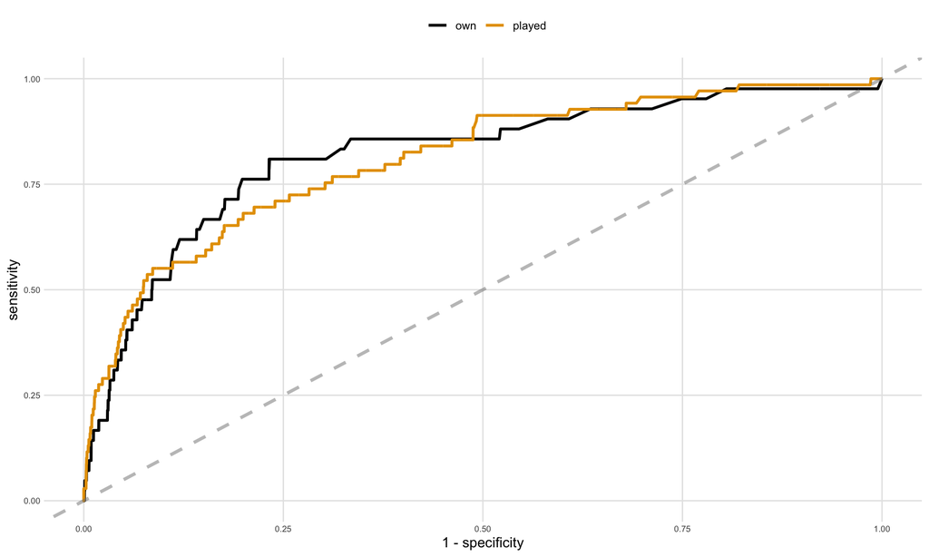

Another way to think about the model performance is to view its lift, or its ability to detect the positive outcomes over that of a null model. High lift indicates the model can much more quickly find all of the positive outcomes (in this case, games owned or played by the user), while a model with no lift is no better than random guessing.

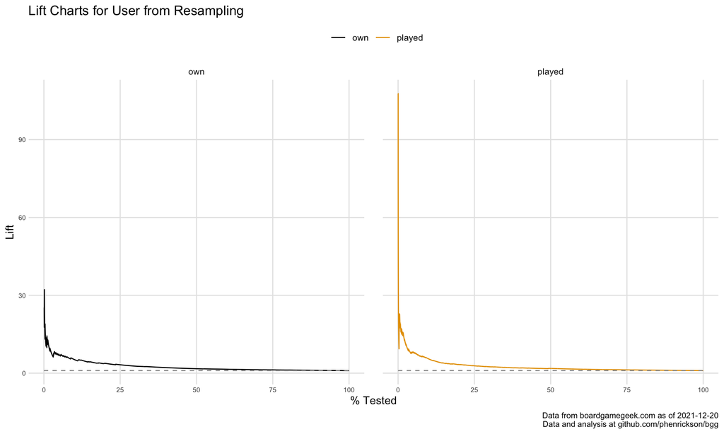

## 3.3 Most and Least Likely Games

What games does the model think ryin12 is **most likely to own** that are **not** in their collection?

| username | yearpublished | game_id | name | pred_own | actual_own |
| --- | --- | --- | --- | --- | --- |
| ryin12 | 2019 | 265736 | Tiny Towns | 0.29 | 0 |
| ryin12 | 2019 | 257066 | Sierra West | 0.22 | 0 |
| ryin12 | 2007 | 29937 | König von Siam | 0.22 | 0 |
| ryin12 | 2019 | 283863 | The Magnificent | 0.20 | 0 |
| ryin12 | 2019 | 270971 | Era: Medieval Age | 0.19 | 0 |

What games does the model think ryin12 is **least likely to own** that **are** in their collection?

| username | yearpublished | game_id | name | pred_own | actual_own |
| --- | --- | --- | --- | --- | --- |
| ryin12 | 2006 | 22245 | Royal Visit | 0 | 1 |
| ryin12 | 2017 | 230802 | Azul | 0 | 1 |
| ryin12 | 1900 | 521 | Crokinole | 0 | 1 |
| ryin12 | 2015 | 140934 | Arboretum | 0 | 1 |
| ryin12 | 2018 | 244992 | The Mind | 0 | 1 |

## 3.4 Top Games by Year

Top 25 games most likely to be owned by the user in each year, highlighting in blue the games that the user has owned/played.

| rank | 2011 | 2012 | 2013 | 2014 | 2015 | 2016 | 2017 | 2018 | 2019 |
| --- | --- | --- | --- | --- | --- | --- | --- | --- | --- |
| 1 | Takenoko | Keyflower | Bomb Squad | Five Tribes | Tiny Epic Galaxies | 1572: The Lost Expedition | Gloomhaven | The Grizzled: Armistice Edition | Tiny Towns |
| 2 | Mage Knight Board Game | Zombicide | City of Remnants | Three Kingdoms Redux | 504 | The Oregon Trail Card Game | Fog of Love | Rising Sun | Sierra West |
| 3 | Tragedy Looper | Il Vecchio | Room 25 | Deception: Murder in Hong Kong | Blood Rage | Mansions of Madness: Second Edition | Magic Maze | Sonar Family | The Magnificent |
| 4 | Pictomania | Space Cadets | Forbidden Desert | HINT | The Grizzled | Bloodborne: The Card Game | The Godfather: Corleone's Empire | The World of SMOG: Rise of Moloch | Era: Medieval Age |
| 5 | Gears of War: The Board Game | Pax Porfiriana | Colonialism | Sons of Anarchy: Men of Mayhem | The King Is Dead | Beyond Baker Street | Raging Bulls | Newton | Paranormal Detectives |
| 6 | Space Empires: 4X | Descent: Journeys in the Dark (Second Edition) | Prosperity | Spyfall | Grand Austria Hotel | Scythe | Gaia Project | Treasure Island | Nanty Narking |
| 7 | Telestrations: 12 Player Party Pack | Robinson Crusoe: Adventures on the Cursed Island | The Ravens of Thri Sahashri | Doodle City | Mysterium | When I Dream | Breaking Bad: The Board Game | Root | Clank!: Legacy – Acquisitions Incorporated |
| 8 | Letters from Whitechapel | Terra Mystica | Legacy: The Testament of Duke de Crecy | Spurs: A Tale in the Old West | ...and then, we held hands. | Pandemic: Iberia | Rum & Bones: Second Tide | Underwater Cities | Maracaibo |
| 9 | Eclipse | Divided Republic | Tash-Kalar: Arena of Legends | Arcadia Quest | Risk: Europe | 13 Days: The Cuban Missile Crisis | Heaven & Ale | Street Masters | Dungeon Academy |
| 10 | A Game of Thrones: The Board Game (Second Edition) | Freedom: The Underground Railroad | Patchistory | Dead of Winter: A Crossroads Game | Zombicide: Black Plague | Inis | Muse | Muse: Awakenings | Last Bastion |
| 11 | Flash Point: Fire Rescue | Bolt Action | Level 7 [Omega Protocol] | Star Wars: Imperial Assault | Loony Quest | Yokohama | Richard the Lionheart | Zombicide: Green Horde | Paladins of the West Kingdom |
| 12 | Panic Station | A Fake Artist Goes to New York | LEADERS: The Combined Strategy Game | La Granja | Chaosmos | Hit Z Road | This War of Mine: The Board Game | Renegade | On Tour |
| 13 | Mansions of Madness | Archipelago | Impulse | Witness | Burgle Bros. | Aeon's End | Massive Darkness | Narcos: The Board Game | Zombicide: Invader |
| 14 | A Few Acres of Snow | Tokaido | Sushi Go! | Golem Arcana | The Bloody Inn | Cry Havoc | Doodle Rush | Once Upon a Castle | Cartographers |
| 15 | Sekigahara: The Unification of Japan | War of the Ring: Second Edition | Concordia | Shadows of Malice | Mombasa | Crazy Karts | Mythic Battles: Pantheon | Pax Emancipation | The Isle of Cats |
| 16 | Drako: Dragon & Dwarves | Spartacus: A Game of Blood and Treachery | Dungeon Command: Blood of Gruumsh | Gaïa | The Voyages of Marco Polo | Exceed Fighting System | Photosynthesis | Western Legends | Middara: Unintentional Malum – Act 1 |
| 17 | Ventura | Wiz-War (Eighth Edition) | BattleLore: Second Edition | Heroes of Normandie | Steampunk Rally | Comanchería: The Rise and Fall of the Comanche Empire | Sonar | The Pirate Republic | Unmatched: Battle of Legends, Volume One |
| 18 | The Castles of Burgundy | Clash of Cultures | Crusade and Revolution: The Spanish Civil War, 1936-1939 | Fleet Commander: 1 – Ignition | Telestrations After Dark | Meeple War | Too Many Bones | Architects of the West Kingdom | Tainted Grail: The Fall of Avalon |
| 19 | Pantheon | Smash Up | Dungeon Twister: The Card Game | Akrotiri | Alien vs Predator: The Hunt Begins | Clank!: A Deck-Building Adventure | 878 Vikings: Invasions of England | Bukiet | ARTBOX |
| 20 | Village | Exodus: Proxima Centauri | Metallum | Smash Up: Monster Smash | The Game | Banana Bandits | Kokoro: Avenue of the Kodama | Let's Make a Bus Route | Tapestry |
| 21 | Feudalia | Saint Malo | Smash Up: The Obligatory Cthulhu Set | Patchwork | Wing Leader: Victories 1940-1942 | Forged in Steel | Twilight Imperium: Fourth Edition | A Song of Ice & Fire: Tabletop Miniatures Game – Stark vs Lannister Starter Set | Blitzkrieg!: World War Two in 20 Minutes |
| 22 | Urban Sprawl | Escape: The Curse of the Temple | Batman: Arkham City Escape | Fields of Arle | Warhammer Age of Sigmar | A Feast for Odin | Masmorra: Dungeons of Arcadia | Kero | Unmatched: Robin Hood vs. Bigfoot |
| 23 | Ora et Labora | Mage Wars Arena | Dungeon Heroes | Star Realms | The U.S. Civil War | Pathfinder Adventure Card Game: Mummy's Mask – Base Set | Mountains of Madness | The Order of Vampire Hunters | Black Rose Wars |
| 24 | Santiago de Cuba | Dungeon Command: Heart of Cormyr | Rivet Wars: Eastern Front | Onitama | Sylvion | Agricola (Revised Edition) | Sunflower Valley | Expancity | Cloudspire |
| 25 | Ninjato | Dungeon Command: Curse of Undeath | Hoplomachus: Rise of Rome | Onirim (Second Edition) | Hoplomachus: Origins | Assembly | Aristeia! | The Edge: Dawnfall | God of War: The Card Game |

## 3.5 Interactive Predictions from Resampling

Interactive table for predictions from resampling.

|  | username | yearpublished | rank | game_id | name | pred_played | pred_own | actual_played | actual_own |
| --- | --- | --- | --- | --- | --- | --- | --- | --- | --- |
| 1 | ryin12 | 1900 | 339 | 2785 | Game of Goose | 0.01 | 0.02 | 0 | 0 |
| 2 | ryin12 | 1900 | 498 | 2397 | Backgammon | 0.01 | 0.01 | 0 | 0 |
| 3 | ryin12 | 1900 | 1392 | 5432 | Chutes and Ladders | 0.01 | 0.01 | 0 | 0 |
| 4 | ryin12 | 1900 | 1744 | 5546 | Marbles | 0 | 0 | 0 | 0 |
| 5 | ryin12 | 1900 | 1747 | 11901 | Tic-Tac-Toe | 0 | 0 | 0 | 0 |
| 6 | ryin12 | 1900 | 1772 | 188 | Go | 0 | 0 | 0 | 0 |
| 7 | ryin12 | 1900 | 1848 | 171 | Chess | 0 | 0 | 0 | 0 |
| 8 | ryin12 | 1900 | 1855 | 2065 | Shogi | 0.01 | 0 | 0 | 0 |
| 9 | ryin12 | 1900 | 1857 | 2393 | Xiangqi | 0 | 0 | 0 | 0 |
| 10 | ryin12 | 1900 | 2040 | 26952 | International Checkers | 0 | 0 | 0 | 0 |

[output cut: 7426 more lines]

# 4 Validating the Model on 2020

How well did a model trained on a user’s collection through 2019 perform in predicting games for the user from 2020?

| username | outcome_type | yearpublished | .metric | .estimator | .estimate |
| --- | --- | --- | --- | --- | --- |
| ryin12 | own | 2020 | roc_auc | binary | 0.733 |
| ryin12 | played | 2020 | roc_auc | binary | 0.805 |

Table of top 25 games from 2020, highlighting games that the user owns.

| username | yearpublished | game_id | name | pred_own | pred_played | actual_own | actual_played |
| --- | --- | --- | --- | --- | --- | --- | --- |
| ryin12 | 2020 | 291457 | Gloomhaven: Jaws of the Lion | 0.28 | 0.60 | 1 | 1 |
| ryin12 | 2020 | 256317 | Guild Master | 0.16 | 0.25 | 0 | 0 |
| ryin12 | 2020 | 184267 | On Mars | 0.13 | 0.30 | 0 | 0 |
| ryin12 | 2020 | 292333 | Cowboys II: Cowboys & Indians Edition | 0.12 | 0.13 | 0 | 0 |
| ryin12 | 2020 | 300322 | Hallertau | 0.09 | 0.13 | 0 | 0 |
| ryin12 | 2020 | 306481 | Tawantinsuyu: The Inca Empire | 0.08 | 0.07 | 0 | 0 |
| ryin12 | 2020 | 246900 | Eclipse: Second Dawn for the Galaxy | 0.06 | 0.12 | 1 | 1 |
| ryin12 | 2020 | 266188 | Seven Bridges | 0.06 | 0.05 | 0 | 0 |
| ryin12 | 2020 | 253506 | Versailles 1919 | 0.05 | 0.05 | 0 | 0 |
| ryin12 | 2020 | 308765 | Praga Caput Regni | 0.05 | 0.04 | 0 | 0 |
| ryin12 | 2020 | 256999 | Project: ELITE | 0.04 | 0.04 | 0 | 0 |
| ryin12 | 2020 | 267009 | Rome & Roll | 0.04 | 0.05 | 0 | 0 |
| ryin12 | 2020 | 295905 | Cosmic Frog | 0.04 | 0.05 | 0 | 0 |
| ryin12 | 2020 | 299179 | Chancellorsville 1863 | 0.04 | 0.04 | 0 | 0 |
| ryin12 | 2020 | 301880 | Raiders of Scythia | 0.04 | 0.02 | 0 | 0 |
| ryin12 | 2020 | 302465 | Obsidia | 0.04 | 0.15 | 0 | 0 |
| ryin12 | 2020 | 308652 | Age of Dogfights: WW1 | 0.04 | 0.04 | 0 | 0 |
| ryin12 | 2020 | 313349 | Indus 2500 BCE | 0.04 | 0.05 | 0 | 0 |
| ryin12 | 2020 | 313531 | Blätterrauschen | 0.04 | 0.04 | 0 | 0 |
| ryin12 | 2020 | 256940 | Krosmaster: Blast | 0.03 | 0.05 | 0 | 0 |
| ryin12 | 2020 | 257193 | Starcadia Quest | 0.03 | 0.04 | 0 | 0 |
| ryin12 | 2020 | 262274 | D6: Dungeons, Dudes, Dames, Danger, Dice and Dragons! | 0.03 | 0.04 | 0 | 0 |
| ryin12 | 2020 | 277927 | Bites | 0.03 | 0.03 | 0 | 0 |
| ryin12 | 2020 | 282922 | Windward | 0.03 | 0.10 | 0 | 0 |
| ryin12 | 2020 | 296151 | Viscounts of the West Kingdom | 0.03 | 0.04 | 0 | 0 |

# 5 Predicting Upcoming Games (2020 and On) for **ryin12**

Examine the top games for the test set.

| username | yearpublished | game_id | name | rank | own | played |
| --- | --- | --- | --- | --- | --- | --- |
| ryin12 | 2020 | 291457 | Gloomhaven: Jaws of the Lion | 1 | 0.28 | 0.60 |
| ryin12 | 2020 | 256317 | Guild Master | 2 | 0.16 | 0.25 |
| ryin12 | 2020 | 184267 | On Mars | 3 | 0.13 | 0.30 |
| ryin12 | 2020 | 292333 | Cowboys II: Cowboys & Indians Edition | 4 | 0.12 | 0.13 |
| ryin12 | 2020 | 300322 | Hallertau | 5 | 0.09 | 0.13 |
| ryin12 | 2020 | 306481 | Tawantinsuyu: The Inca Empire | 6 | 0.08 | 0.07 |
| ryin12 | 2020 | 266188 | Seven Bridges | 7 | 0.06 | 0.05 |
| ryin12 | 2020 | 246900 | Eclipse: Second Dawn for the Galaxy | 8 | 0.06 | 0.12 |
| ryin12 | 2020 | 253506 | Versailles 1919 | 9 | 0.05 | 0.05 |
| ryin12 | 2020 | 308765 | Praga Caput Regni | 10 | 0.05 | 0.04 |
| ryin12 | 2020 | 267009 | Rome & Roll | 11 | 0.04 | 0.05 |
| ryin12 | 2020 | 256999 | Project: ELITE | 12 | 0.04 | 0.04 |
| ryin12 | 2020 | 295905 | Cosmic Frog | 13 | 0.04 | 0.05 |
| ryin12 | 2020 | 301880 | Raiders of Scythia | 14 | 0.04 | 0.02 |
| ryin12 | 2020 | 299179 | Chancellorsville 1863 | 15 | 0.04 | 0.04 |
| ryin12 | 2020 | 302465 | Obsidia | 16 | 0.04 | 0.15 |
| ryin12 | 2020 | 308652 | Age of Dogfights: WW1 | 17 | 0.04 | 0.04 |
| ryin12 | 2020 | 313349 | Indus 2500 BCE | 18 | 0.04 | 0.05 |
| ryin12 | 2020 | 313531 | Blätterrauschen | 19 | 0.04 | 0.04 |
| ryin12 | 2020 | 316750 | The Princess Bride Adventure Book Game | 20 | 0.03 | 0.08 |
| ryin12 | 2020 | 296151 | Viscounts of the West Kingdom | 21 | 0.03 | 0.04 |
| ryin12 | 2020 | 297030 | Tekhenu: Obelisk of the Sun | 22 | 0.03 | 0.03 |
| ryin12 | 2020 | 262274 | D6: Dungeons, Dudes, Dames, Danger, Dice and Dragons! | 23 | 0.03 | 0.04 |
| ryin12 | 2020 | 324246 | Journey to the Center of the Earth | 24 | 0.03 | 0.06 |
| ryin12 | 2020 | 257193 | Starcadia Quest | 25 | 0.03 | 0.04 |
| ryin12 | 2021 | 298102 | Roll Camera!: The Filmmaking Board Game | 1 | 0.19 | 0.20 |
| ryin12 | 2021 | 310873 | Carnegie | 2 | 0.15 | 0.23 |
| ryin12 | 2021 | 285967 | Ankh: Gods of Egypt | 3 | 0.14 | 0.17 |
| ryin12 | 2021 | 249277 | Brazil: Imperial | 4 | 0.14 | 0.09 |
| ryin12 | 2021 | 343905 | Boonlake | 5 | 0.12 | 0.11 |
| ryin12 | 2021 | 318084 | Furnace | 6 | 0.09 | 0.09 |
| ryin12 | 2021 | 335541 | We Care: a Grizzled Game | 7 | 0.08 | 0.07 |
| ryin12 | 2021 | 273330 | Bloodborne: The Board Game | 8 | 0.05 | 0.08 |
| ryin12 | 2021 | 319263 | One Card Dungeon | 9 | 0.05 | 0.05 |
| ryin12 | 2021 | 316786 | Tabannusi: Builders of Ur | 10 | 0.05 | 0.04 |
| ryin12 | 2021 | 306881 | Railroad Ink Challenge: Lush Green Edition | 11 | 0.04 | 0.03 |
| ryin12 | 2021 | 306882 | Railroad Ink Challenge: Shining Yellow Edition | 12 | 0.04 | 0.03 |
| ryin12 | 2021 | 335678 | Let's Make a Bus Route: The Dice Game | 13 | 0.04 | 0.03 |
| ryin12 | 2021 | 315767 | Cartographers Heroes | 14 | 0.04 | 0.05 |
| ryin12 | 2021 | 300217 | Merchants of the Dark Road | 15 | 0.04 | 0.03 |
| ryin12 | 2021 | 291572 | Oath: Chronicles of Empire and Exile | 16 | 0.04 | 0.07 |
| ryin12 | 2021 | 251661 | Oathsworn: Into the Deepwood | 17 | 0.04 | 0.14 |
| ryin12 | 2021 | 340237 | Wonder Book | 18 | 0.04 | 0.05 |
| ryin12 | 2021 | 286751 | Zombicide: 2nd Edition | 19 | 0.03 | 0.02 |
| ryin12 | 2021 | 341169 | Great Western Trail (Second Edition) | 20 | 0.03 | 0.04 |
| ryin12 | 2021 | 336382 | Marvel United: X-Men | 21 | 0.03 | 0.03 |
| ryin12 | 2021 | 295785 | Euthia: Torment of Resurrection | 22 | 0.03 | 0.07 |
| ryin12 | 2021 | 342942 | Ark Nova | 23 | 0.03 | 0.04 |
| ryin12 | 2021 | 332420 | NEXUM: Galaxy | 24 | 0.02 | 0.13 |
| ryin12 | 2021 | 335764 | Unmatched: Battle of Legends, Volume Two | 25 | 0.02 | 0.11 |
| ryin12 | 2022 | 295770 | Frosthaven | 1 | 0.20 | 0.43 |
| ryin12 | 2022 | 304051 | Creature Comforts | 2 | 0.18 | 0.15 |
| ryin12 | 2022 | 317511 | Tindaya | 3 | 0.12 | 0.25 |
| ryin12 | 2022 | 322524 | Bardsung | 4 | 0.08 | 0.12 |
| ryin12 | 2022 | 331106 | The Witcher: Old World | 5 | 0.08 | 0.30 |
| ryin12 | 2022 | 317321 | Darkest Dungeon: The Board Game | 6 | 0.04 | 0.09 |
| ryin12 | 2022 | 273814 | Deliverance | 7 | 0.04 | 0.06 |
| ryin12 | 2022 | 315610 | Massive Darkness 2: Hellscape | 8 | 0.03 | 0.03 |
| ryin12 | 2022 | 283137 | Human Punishment: The Beginning | 9 | 0.03 | 0.14 |
| ryin12 | 2022 | 326945 | Castles of Mad King Ludwig: Collector's Edition | 10 | 0.03 | 0.05 |
| ryin12 | 2022 | 280726 | Legacies | 11 | 0.03 | 0.04 |
| ryin12 | 2022 | 324090 | Scarface 1920 | 12 | 0.02 | 0.02 |
| ryin12 | 2022 | 331401 | Dog Park | 13 | 0.02 | 0.02 |
| ryin12 | 2022 | 281258 | Sub Terra II: Inferno's Edge | 14 | 0.02 | 0.02 |
| ryin12 | 2022 | 312959 | Rallyman: DIRT | 15 | 0.02 | 0.01 |
| ryin12 | 2022 | 340325 | Vagrantsong | 16 | 0.02 | 0.02 |
| ryin12 | 2022 | 311823 | Nova Aetas Renaissance | 17 | 0.02 | 0.02 |
| ryin12 | 2022 | 321608 | Hegemony: Lead Your Class to Victory | 18 | 0.02 | 0.02 |
| ryin12 | 2022 | 299106 | Fractal: Beyond the Void | 19 | 0.02 | 0.07 |
| ryin12 | 2022 | 305096 | Endless Winter: Paleoamericans | 20 | 0.02 | 0.02 |
| ryin12 | 2022 | 256680 | Return to Dark Tower | 21 | 0.02 | 0.05 |
| ryin12 | 2022 | 338067 | 6: Siege – The Board Game | 22 | 0.02 | 0.04 |
| ryin12 | 2022 | 319807 | Shogun no Katana | 23 | 0.02 | 0.02 |
| ryin12 | 2022 | 219650 | Arydia: The Paths We Dare Tread | 24 | 0.01 | 0.00 |
| ryin12 | 2022 | 240980 | Blood on the Clocktower | 25 | 0.01 | 0.01 |

## 5.1 Interactive Table for Upcoming Games 2020 and On

|  | username | yearpublished | game_id | name | rank | own | played |
| --- | --- | --- | --- | --- | --- | --- | --- |
| 1 | ryin12 | 2020 | 291457 | Gloomhaven: Jaws of the Lion | 1 | 0.28 | 0.6 |
| 2 | ryin12 | 2022 | 295770 | Frosthaven | 2 | 0.2 | 0.43 |
| 3 | ryin12 | 2021 | 298102 | Roll Camera!: The Filmmaking Board Game | 3 | 0.19 | 0.2 |
| 4 | ryin12 | 2022 | 304051 | Creature Comforts | 4 | 0.18 | 0.15 |
| 5 | ryin12 | 2020 | 256317 | Guild Master | 5 | 0.16 | 0.25 |
| 6 | ryin12 | 2021 | 310873 | Carnegie | 6 | 0.15 | 0.23 |
| 7 | ryin12 | 2021 | 285967 | Ankh: Gods of Egypt | 7 | 0.14 | 0.17 |
| 8 | ryin12 | 2021 | 249277 | Brazil: Imperial | 8 | 0.14 | 0.09 |
| 9 | ryin12 | 2020 | 184267 | On Mars | 9 | 0.13 | 0.3 |
| 10 | ryin12 | 2021 | 343905 | Boonlake | 10 | 0.12 | 0.11 |

[output cut: 1627 more lines]